# Data Science for Public Policy

Xiyu Zhang - xz551

```r
library(tidyverse)
library(ipumsr)
library(srvyr)
library(haven)
```

# Exercise 01 (1 point)

```r
library(ipumsr)
library(tidyverse)
ddi <- read_ipums_ddi("cps_00002.xml")
data <- read_ipums_micro(ddi)
```

```
## Use of data from IPUMS CPS is subject to conditions including that users should
## cite the data appropriately. Use command `ipums_conditions()` for more details.
```

```r
glimpse(data)
```

```
## Rows: 212,608
## Columns: 26
## $ YEAR      <dbl> 2020, 2020, 2020, 2020, 2020, 2020, 2020, 2020, 2020, 2020, …
## $ SERIAL    <dbl> 1, 2, 2, 2, 3, 5, 5, 5, 6, 7, 7, 8, 9, 9, 11, 11, 12, 12, 14…
## $ MONTH     <int+lbl> 4, 4, 4, 4, 4, 4, 4, 4, 4, 4, 4, 4, 4, 4, 4, 4, 4, 4, 4,…
## $ HWTFINL   <dbl> 1796.811, 2923.587, 2923.587, 2923.587, 1792.269, 1912.517, …
## $ CPSID     <dbl> 2.02003e+13, 2.02002e+13, 2.02002e+13, 2.02002e+13, 2.02001e…
## $ PERNUM    <dbl> 1, 1, 2, 3, 1, 1, 2, 3, 1, 1, 2, 1, 1, 2, 1, 2, 1, 2, 1, 1, …
## $ WTFINL    <dbl> 1796.811, 2923.587, 3618.171, 4634.866, 1792.269, 1912.517, …
## $ CPSIDP    <dbl> 2.02003e+13, 2.02002e+13, 2.02002e+13, 2.02002e+13, 2.02001e…
## $ RELATE    <int+lbl> 101, 101, 301, 501, 101, 101, 1260, 1260, 101, 101, 202,…
## $ AGE       <int+lbl> 72, 21, 1, 27, 59, 67, 33, 33, 48, 80, 80, 80, 44, 19, 7…
## $ SEX       <int+lbl> 2, 2, 1, 1, 2, 1, 2, 1, 1, 1, 2, 2, 2, 2, 2, 1, 2, 1, 2,…
## $ RACE      <int+lbl> 100, 200, 200, 200, 200, 100, 100, 100, 100, 100, 100, 1…
## $ MARST     <int+lbl> 4, 4, 9, 6, 5, 3, 4, 6, 6, 1, 1, 6, 6, 6, 1, 1, 1, 1, 4,…
## $ POPSTAT   <int+lbl> 1, 1, 3, 1, 1, 1, 1, 1, 1, 1, 1, 1, 1, 1, 1, 1, 1, 1, 1,…
## $ EMPSTAT   <int+lbl> 10, 21, 0, 21, 10, 10, 34, 34, 10, 36, 10, 36, 10, 34, 1…
## $ LABFORCE  <int+lbl> 2, 2, 0, 2, 2, 2, 1, 1, 2, 1, 2, 1, 2, 1, 2, 1, 2, 2, 1,…
## $ OCC       <dbl> 2205, 4720, 0, 710, 3255, 2040, 0, 0, 3930, 0, 4920, 0, 9645…
## $ IND       <dbl> 7870, 8680, 0, 4670, 8191, 9160, 0, 0, 4971, 0, 7071, 0, 629…
## $ UHRSWORKT <int+lbl> 40, 999, 999, 999, 40, 65, 999, 999, 997, 999, 997, 999,…
## $ UHRSWORK1 <int+lbl> 40, 999, 999, 999, 40, 65, 999, 999, 997, 999, 997, 999,…
## $ UHRSWORK2 <int+lbl> 999, 999, 999, 999, 999, 999, 999, 999, 999, 999, 999, 9…
## $ AHRSWORKT <dbl+lbl>  40, 999, 999, 999,  40,  40, 999, 999,  45, 999,  24, 9…
## $ AHRSWORK1 <int+lbl> 40, 999, 999, 999, 40, 40, 999, 999, 45, 999, 24, 999, 4…
## $ AHRSWORK2 <int+lbl> 999, 999, 999, 999, 999, 999, 999, 999, 999, 999, 999, 9…
## $ ABSENT    <int+lbl> 0, 2, 0, 2, 0, 0, 1, 1, 0, 1, 0, 1, 0, 1, 3, 1, 0, 0, 1,…
## $ WKSTAT    <int+lbl> 11, 60, 99, 50, 11, 11, 99, 99, 11, 99, 41, 99, 11, 99, …
```

# Exercise 02 (2 points)

#2.

```r
library(srvyr)
cps_svy <- as_survey_design(data, weights = WTFINL)
class(data)
```

```
## [1] "tbl_df"     "tbl"        "data.frame"
```

```r
class(cps_svy)
```

```
## [1] "tbl_svy"        "survey.design2" "survey.design"
```

#3. The difference is that, the as_survey_design function turn the tibble into a “tbl_svy”, object, and create two new catagories called “survey.design” & “survey.design2”

#4. Yes, there is a value of NIU: #for UHRSWORKT, 1999-onward ASEC:0 = No hours; 997 = Hours vary; 999 = Not in universe (NIU) #for AHRSWORKT, 999 = NIU (Not in universe)

```r
NIU.UHR.AHR <- data %>%
  group_by(YEAR, UHRSWORKT, AHRSWORKT) %>%
  summarise(
    unweighted = n()
  ) %>%
  filter(UHRSWORKT == 999 | AHRSWORKT == 999) %>%
  arrange(YEAR, desc(UHRSWORKT))
NIU.UHR.AHR
```

| YEAR | UHRSWORKT | AHRSWORKT | unweighted |
| --- | --- | --- | --- |
| 2020 | 999 | 999 | 59895 |
| 2020 | 997 | 999 | 345 |
| 2020 | 100 | 999 | 2 |
| 2020 | 99 | 999 | 1 |
| 2020 | 90 | 999 | 5 |
| 2020 | 89 | 999 | 1 |
| 2020 | 84 | 999 | 4 |
| 2020 | 82 | 999 | 1 |
| 2020 | 80 | 999 | 12 |
| 2020 | 74 | 999 | 1 |

[output cut: 118 more lines]

#observed that for all observations in 2020 and 2021, while UHRSWORKT == 999, then AHRSWORKT is inevitabily 999, that means to sum up the observations that are not in the universe in these two years, we could only group_by the AHRSWORKT variable. Rewrite our code:

```r
NIU.UHR.AHR <- data %>%
  group_by(YEAR, AHRSWORKT) %>%
  summarise(
    unweighted = n()
  ) %>%
  filter(AHRSWORKT == 999) %>%
  arrange(YEAR, desc(AHRSWORKT))
NIU.UHR.AHR
```

| YEAR | AHRSWORKT | unweighted |
| --- | --- | --- |
| 2020 | 999 | 63321 |
| 2021 | 999 | 61703 |

#Thus, in 2020, there were 63321 observations that are not in the universe for UHRSWORKT and AHRSWORKT; in 2021, there were 61703 of them.

#5.Filter out observations not in the universe for UHRSWORKT and create a new data frame called cps_subset_svy with the assignment operator.

```r
cps_subset_svy <- data %>%
  filter(UHRSWORKT != 999)
cps_subset_svy
```

| YEAR | SERIAL | MONTH | HWTFINL | CPSID | PERNUM | WTFINL | CPSIDP | RELATE | AGE | SEX | RACE | MARST | POPSTAT | EMPSTAT | LABFORCE | OCC | IND | UHRSWORKT | UHRSWORK1 | UHRSWORK2 | AHRSWORKT | AHRSWORK1 | AHRSWORK2 | ABSENT | WKSTAT |
| --- | --- | --- | --- | --- | --- | --- | --- | --- | --- | --- | --- | --- | --- | --- | --- | --- | --- | --- | --- | --- | --- | --- | --- | --- | --- |
| 2020 | 1 | 4 | 1796.8107 | 2.02003e+13 | 1 | 1796.8107 | 2.02003e+13 | 101 | 72 | 2 | 100 | 4 | 1 | 10 | 2 | 2205 | 7870 | 40 | 40 | 999 | 40 | 40 | 999 | 0 | 11 |
| 2020 | 3 | 4 | 1792.2691 | 2.02001e+13 | 1 | 1792.2691 | 2.02001e+13 | 101 | 59 | 2 | 200 | 5 | 1 | 10 | 2 | 3255 | 8191 | 40 | 40 | 999 | 40 | 40 | 999 | 0 | 11 |
| 2020 | 5 | 4 | 1912.5170 | 2.02001e+13 | 1 | 1912.5170 | 2.02001e+13 | 101 | 67 | 1 | 100 | 3 | 1 | 10 | 2 | 2040 | 9160 | 65 | 65 | 999 | 40 | 40 | 999 | 0 | 11 |
| 2020 | 6 | 4 | 1999.5770 | 2.02002e+13 | 1 | 1999.5770 | 2.02002e+13 | 101 | 48 | 1 | 100 | 6 | 1 | 10 | 2 | 3930 | 4971 | 997 | 997 | 999 | 45 | 45 | 999 | 0 | 11 |
| 2020 | 7 | 4 | 1966.7023 | 2.02003e+13 | 2 | 1966.7023 | 2.02003e+13 | 202 | 80 | 2 | 100 | 1 | 1 | 10 | 2 | 4920 | 7071 | 997 | 997 | 999 | 24 | 24 | 999 | 0 | 41 |
| 2020 | 9 | 4 | 3407.3006 | 2.02003e+13 | 1 | 3407.3006 | 2.02003e+13 | 101 | 44 | 2 | 200 | 6 | 1 | 10 | 2 | 9645 | 6290 | 40 | 40 | 999 | 40 | 40 | 999 | 0 | 11 |
| 2020 | 11 | 4 | 1966.7023 | 2.02003e+13 | 1 | 1966.7023 | 2.02003e+13 | 101 | 75 | 2 | 100 | 1 | 1 | 12 | 2 | 4920 | 7071 | 40 | 40 | 999 | 999 | 999 | 999 | 3 | 13 |
| 2020 | 12 | 4 | 2457.3428 | 2.01903e+13 | 1 | 2457.3428 | 2.01903e+13 | 101 | 47 | 2 | 200 | 1 | 1 | 10 | 2 | 3645 | 8090 | 26 | 26 | 999 | 26 | 26 | 999 | 0 | 41 |
| 2020 | 12 | 4 | 2457.3428 | 2.01903e+13 | 2 | 2477.1342 | 2.01903e+13 | 202 | 45 | 1 | 200 | 1 | 1 | 10 | 2 | 5610 | 6390 | 40 | 40 | 999 | 20 | 20 | 999 | 0 | 12 |
| 2020 | 20 | 4 | 1794.4605 | 2.01902e+13 | 2 | 1940.1158 | 2.01902e+13 | 202 | 46 | 1 | 100 | 1 | 1 | 10 | 2 | 8140 | 3680 | 40 | 40 | 999 | 30 | 30 | 999 | 0 | 21 |

[output cut: 9990 more lines]

#6.Count the number of unweighted responses for each value for UHRSWORKT.

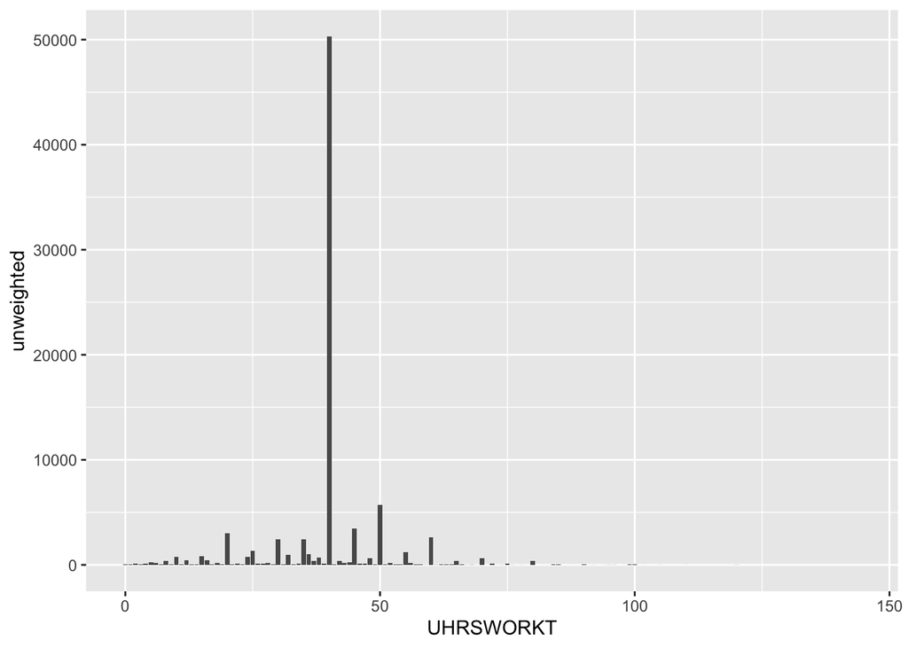

```r
cps_subset_6 <- cps_subset_svy %>%
  group_by(UHRSWORKT) %>%
  filter(UHRSWORKT != 997) %>%
  summarize (
    unweighted = n()
  )
ggplot(data = cps_subset_6) +
  geom_col(mapping = aes(x = UHRSWORKT, y = unweighted))
```

#7.Calculate the mean usual hours worked (UHRSWORKT) in 2020 and 2021. Exclude workers with “Hours vary”.

```r
cps_subset_7 <- cps_subset_svy %>%
  group_by(YEAR) %>%
  filter(UHRSWORKT != 997) %>%
  summarise(mean_UHRSWORKT = mean(UHRSWORKT))
cps_subset_7
```

| YEAR | mean_UHRSWORKT |
| --- | --- |
| 2020 | 39.73370 |
| 2021 | 39.39469 |

#8.Calculate the proportion of workers who usually worked exactly 40 hours in 2021.

```r
cps_subset_8 <- cps_subset_svy %>%
  filter(YEAR == 2021) %>%
  mutate(
    HOURS_40 = if_else(condition = UHRSWORKT == 40, true = 1, false = 0)
    ) %>%
  group_by(YEAR) %>%
  summarise(proportion_40 = mean(HOURS_40))
cps_subset_8
```

| YEAR | proportion_40 |
| --- | --- |
| 2021 | 0.533625 |

#9.Calculate the proportion of workers who worked less, the same, and more than usual in April 2020 and April 2021 (separately) by comparing UHRSWORKT and AHRSWORKT.

```r
cps_subset_91 <- cps_subset_svy %>%
  filter(UHRSWORKT != 997) %>%
  select(YEAR, UHRSWORKT, AHRSWORKT) %>%
  mutate(
    AprilWork = case_when(
      AHRSWORKT > UHRSWORKT ~ "work more",
      AHRSWORKT < UHRSWORKT ~ "work less",
      TRUE ~ "work the same"
    )
  )
cps_subset_92 <- as_survey_design(cps_subset_91) %>%
  group_by(YEAR, AprilWork) %>%
  summarise(prop = survey_prop())
cps_subset_92
```

| YEAR | AprilWork | prop | prop_se |
| --- | --- | --- | --- |
| 2020 | work less | 0.17164504 | 0.001907701 |
| 2020 | work more | 0.15022140 | 0.001807612 |
| 2020 | work the same | 0.67813356 | 0.002363643 |
| 2021 | work less | 0.09700939 | 0.001362597 |
| 2021 | work more | 0.10902694 | 0.001434888 |
| 2021 | work the same | 0.79396367 | 0.001862049 |

# Exercise 03 (2 points)

#2. Using cps_svy, calculate the weighted count of observations ages 16 or older for each year with survey_count(). Your results should match the April 2020 and April 2021 values to the closest thousand because of rounding. #Sorry I don’t have any idea about “survey_count”, it seems not appear when I was trying to search it. I also don’t know how to put the age >= 16 into weight.

#3. Create three numeric indicator variables.

```r
cps_svy_33 <- cps_svy %>%
  mutate(
    labor_force = case_when(
      LABFORCE == 2 ~ 1,
      LABFORCE == 1 ~ 0,
      TRUE ~ 999
    )
  ) %>%
  mutate(
    employed = case_when(
      EMPSTAT == 10 | EMPSTAT == 12 ~ 1,
      EMPSTAT == 20 | EMPSTAT == 21 | EMPSTAT == 22 ~ 0,
      TRUE ~ 999
    )
  ) %>%
  mutate(
    unemployed = case_when(
      EMPSTAT == 10 | EMPSTAT == 12 ~ 0,
      EMPSTAT == 20 | EMPSTAT == 21 | EMPSTAT == 22 ~ 1,
      TRUE ~ 999
    )
  )
```

#4.Filter to the civilian population ages 16 or older, and calculate the relavant population.

```r
cps_svy_34 <- cps_svy_33 %>%
  filter(AGE >= 16) %>%
  filter(POPSTAT == 1) %>%
  summarise(
    LABFOR_cal = survey_total(labor_force == 1),
    EMPLOY_cal = survey_total(employed == 1),
    UNEMPLOY_cal = survey_total(unemployed == 1)
            )
cps_svy_34
```

| LABFOR_cal | LABFOR_cal_se | EMPLOY_cal | EMPLOY_cal_se | UNEMPLOY_cal | UNEMPLOY_cal_se |
| --- | --- | --- | --- | --- | --- |
| 316601435 | 922159.7 | 284601546 | 891906.2 | 31999889 | 374905 |

#5. Compare the result with microdata to the official tabulation for April 2021. #The official data is: civilian labor force - 160,379,000; employed - 151,160,000; unemployed - 9,220,000. #What I got here are (shown above): civilian labor force - 316,601,435; employed - 284,601,546; unemployed - 31,999,889. They are far from “close”, thus there might be some problems in my code.

# Exercise 04 (2 points)

#1.-3

```r
cps2021 <- filter(data, YEAR == 2021)
cps2021_sum <- cps2021 %>%
  summarise(n())
cps2021_sum
```

| n() |
| --- |
| 111003 |

```r
nber <- read_dta("cpsb202104.dta")
nber_sum <- nber %>%
  select(hufinal, pwcmpwgt) %>%
  summarise(n())
nber_sum
```

| n() |
| --- |
| 133449 |

#3. Notice that n = 133,449. There are 133,449 observations in dataset “nber”, while there are 111,003 observations in dataset “cps2021”.

#4.

```r
nber_44 <- nber %>%
  filter(hufinal <= 205) %>%
  summarise(n())
nber_44
```

| n() |
| --- |
| 111003 |

# Exercise 05 (2 points)